# Risk Factor Analysis

## Outcome Variable

**Outcome Variable:** y_rate_haz

## Predictor Variables

**Intervention Variable:** earlybf

**Adjustment Set:**

unadjusted

## Stratifying Variables

The analysis was stratified on these variable(s):

- agecat
- studyid
- country

## Data Summary

| agecat | studyid | country | earlybf | n_cell | n |
| --- | --- | --- | --- | --- | --- |
| 0-3 months | ki0047075b-MAL-ED | BANGLADESH | 0 | 92 | 243 |
| 0-3 months | ki0047075b-MAL-ED | BANGLADESH | 1 | 151 | 243 |
| 0-3 months | ki0047075b-MAL-ED | BRAZIL | 0 | 102 | 180 |
| 0-3 months | ki0047075b-MAL-ED | BRAZIL | 1 | 78 | 180 |
| 0-3 months | ki0047075b-MAL-ED | INDIA | 0 | 81 | 201 |
| 0-3 months | ki0047075b-MAL-ED | INDIA | 1 | 120 | 201 |
| 0-3 months | ki0047075b-MAL-ED | NEPAL | 0 | 97 | 175 |
| 0-3 months | ki0047075b-MAL-ED | NEPAL | 1 | 78 | 175 |
| 0-3 months | ki0047075b-MAL-ED | PERU | 0 | 68 | 271 |
| 0-3 months | ki0047075b-MAL-ED | PERU | 1 | 203 | 271 |
| 0-3 months | ki0047075b-MAL-ED | SOUTH AFRICA | 0 | 80 | 226 |
| 0-3 months | ki0047075b-MAL-ED | SOUTH AFRICA | 1 | 146 | 226 |
| 0-3 months | ki0047075b-MAL-ED | TANZANIA, UNITED REPUBLIC OF | 0 | 32 | 229 |
| 0-3 months | ki0047075b-MAL-ED | TANZANIA, UNITED REPUBLIC OF | 1 | 197 | 229 |
| 0-3 months | ki1000109-EE | PAKISTAN | 0 | 486 | 594 |
| 0-3 months | ki1000109-EE | PAKISTAN | 1 | 108 | 594 |
| 0-3 months | ki1000304b-SAS-CompFeed | INDIA | 0 | 1080 | 1168 |
| 0-3 months | ki1000304b-SAS-CompFeed | INDIA | 1 | 88 | 1168 |
| 0-3 months | ki1017093c-NIH-Crypto | BANGLADESH | 0 | 98 | 720 |
| 0-3 months | ki1017093c-NIH-Crypto | BANGLADESH | 1 | 622 | 720 |
| 0-3 months | ki1126311-ZVITAMBO | ZIMBABWE | 0 | 3255 | 6970 |
| 0-3 months | ki1126311-ZVITAMBO | ZIMBABWE | 1 | 3715 | 6970 |
| 0-3 months | kiGH5241-JiVitA-3 | BANGLADESH | 0 | 39980 | 40090 |
| 0-3 months | kiGH5241-JiVitA-3 | BANGLADESH | 1 | 110 | 40090 |
| 0-3 months | kiGH5241-JiVitA-4 | BANGLADESH | 0 | 1024 | 3614 |
| 0-3 months | kiGH5241-JiVitA-4 | BANGLADESH | 1 | 2590 | 3614 |
| 3-6 months | ki0047075b-MAL-ED | BANGLADESH | 0 | 90 | 230 |
| 3-6 months | ki0047075b-MAL-ED | BANGLADESH | 1 | 140 | 230 |
| 3-6 months | ki0047075b-MAL-ED | BRAZIL | 0 | 113 | 208 |
| 3-6 months | ki0047075b-MAL-ED | BRAZIL | 1 | 95 | 208 |

[output cut: 76 more lines]

The following strata were considered:

- agecat: 0-3 months, studyid: ki0047075b-MAL-ED, country: BANGLADESH
- agecat: 0-3 months, studyid: ki0047075b-MAL-ED, country: BRAZIL
- agecat: 0-3 months, studyid: ki0047075b-MAL-ED, country: INDIA
- agecat: 0-3 months, studyid: ki0047075b-MAL-ED, country: NEPAL
- agecat: 0-3 months, studyid: ki0047075b-MAL-ED, country: PERU
- agecat: 0-3 months, studyid: ki0047075b-MAL-ED, country: SOUTH AFRICA
- agecat: 0-3 months, studyid: ki0047075b-MAL-ED, country: TANZANIA, UNITED REPUBLIC OF
- agecat: 0-3 months, studyid: ki1000109-EE, country: PAKISTAN
- agecat: 0-3 months, studyid: ki1000304b-SAS-CompFeed, country: INDIA
- agecat: 0-3 months, studyid: ki1017093c-NIH-Crypto, country: BANGLADESH
- agecat: 0-3 months, studyid: ki1126311-ZVITAMBO, country: ZIMBABWE
- agecat: 0-3 months, studyid: kiGH5241-JiVitA-3, country: BANGLADESH
- agecat: 0-3 months, studyid: kiGH5241-JiVitA-4, country: BANGLADESH
- agecat: 12-24 months, studyid: ki0047075b-MAL-ED, country: BANGLADESH
- agecat: 12-24 months, studyid: ki0047075b-MAL-ED, country: BRAZIL
- agecat: 12-24 months, studyid: ki0047075b-MAL-ED, country: INDIA
- agecat: 12-24 months, studyid: ki0047075b-MAL-ED, country: NEPAL
- agecat: 12-24 months, studyid: ki0047075b-MAL-ED, country: PERU
- agecat: 12-24 months, studyid: ki0047075b-MAL-ED, country: SOUTH AFRICA
- agecat: 12-24 months, studyid: ki0047075b-MAL-ED, country: TANZANIA, UNITED REPUBLIC OF
- agecat: 12-24 months, studyid: ki1017093c-NIH-Crypto, country: BANGLADESH
- agecat: 12-24 months, studyid: ki1113344-GMS-Nepal, country: NEPAL
- agecat: 12-24 months, studyid: ki1126311-ZVITAMBO, country: ZIMBABWE
- agecat: 12-24 months, studyid: kiGH5241-JiVitA-3, country: BANGLADESH
- agecat: 12-24 months, studyid: kiGH5241-JiVitA-4, country: BANGLADESH
- agecat: 3-6 months, studyid: ki0047075b-MAL-ED, country: BANGLADESH
- agecat: 3-6 months, studyid: ki0047075b-MAL-ED, country: BRAZIL
- agecat: 3-6 months, studyid: ki0047075b-MAL-ED, country: INDIA
- agecat: 3-6 months, studyid: ki0047075b-MAL-ED, country: NEPAL
- agecat: 3-6 months, studyid: ki0047075b-MAL-ED, country: PERU
- agecat: 3-6 months, studyid: ki0047075b-MAL-ED, country: SOUTH AFRICA
- agecat: 3-6 months, studyid: ki0047075b-MAL-ED, country: TANZANIA, UNITED REPUBLIC OF
- agecat: 3-6 months, studyid: ki1000109-EE, country: PAKISTAN
- agecat: 3-6 months, studyid: ki1000304b-SAS-CompFeed, country: INDIA
- agecat: 3-6 months, studyid: ki1017093c-NIH-Crypto, country: BANGLADESH
- agecat: 3-6 months, studyid: ki1113344-GMS-Nepal, country: NEPAL
- agecat: 3-6 months, studyid: ki1126311-ZVITAMBO, country: ZIMBABWE
- agecat: 3-6 months, studyid: kiGH5241-JiVitA-3, country: BANGLADESH
- agecat: 3-6 months, studyid: kiGH5241-JiVitA-4, country: BANGLADESH
- agecat: 6-12 months, studyid: ki0047075b-MAL-ED, country: BANGLADESH
- agecat: 6-12 months, studyid: ki0047075b-MAL-ED, country: BRAZIL
- agecat: 6-12 months, studyid: ki0047075b-MAL-ED, country: INDIA
- agecat: 6-12 months, studyid: ki0047075b-MAL-ED, country: NEPAL
- agecat: 6-12 months, studyid: ki0047075b-MAL-ED, country: PERU
- agecat: 6-12 months, studyid: ki0047075b-MAL-ED, country: SOUTH AFRICA
- agecat: 6-12 months, studyid: ki0047075b-MAL-ED, country: TANZANIA, UNITED REPUBLIC OF
- agecat: 6-12 months, studyid: ki1000109-EE, country: PAKISTAN
- agecat: 6-12 months, studyid: ki1000304b-SAS-CompFeed, country: INDIA
- agecat: 6-12 months, studyid: ki1017093c-NIH-Crypto, country: BANGLADESH
- agecat: 6-12 months, studyid: ki1113344-GMS-Nepal, country: NEPAL
- agecat: 6-12 months, studyid: ki1126311-ZVITAMBO, country: ZIMBABWE
- agecat: 6-12 months, studyid: kiGH5241-JiVitA-3, country: BANGLADESH
- agecat: 6-12 months, studyid: kiGH5241-JiVitA-4, country: BANGLADESH

### Dropped Strata

Some strata were dropped due to rare outcomes:

- agecat: 6-12 months, studyid: ki1000109-EE, country: PAKISTAN
- agecat: 6-12 months, studyid: kiGH5241-JiVitA-3, country: BANGLADESH
- agecat: 12-24 months, studyid: kiGH5241-JiVitA-3, country: BANGLADESH

## Methods Detail

We’re interested in the causal parameters $E[Y_a]$ for all values of $a \in \mathcal{A}$. These parameters represent the mean outcome if, possibly contrary to fact, we intervened to set all units to have $A=a$. Under the randomization and positivity assumptions, these are identified by the statistical parameters $\psi_a=E_W[E_{Y|A,W}(Y|A=a,W)]$. In addition, we’re interested in the mean of $Y$, $E[Y]$ under no intervention (the observed mean). We will estimate these parameters by using SuperLearner to fit the relevant likelihood factors – $E_{Y|A,W}(Y|A=a,W)$ and $p(A=a|W)$, and then updating our likelihood fit using a joint TMLE.

For unadjusted analyses ($W=\{\}$), initial likelihoods were estimated using Lrnr_glm to estimate the simple $E(Y|A)$ and Lrnr_mean to estimate $p(A)$. For adjusted analyses, a small library containing Lrnr_glmnet, Lrnr_xgboost, and Lrnr_mean was used.

Having estimated these parameters, we will then use the delta method to estimate relative risks and attributable risks relative to a prespecified baseline level of $A$.

# Results Detail

## Results Plots

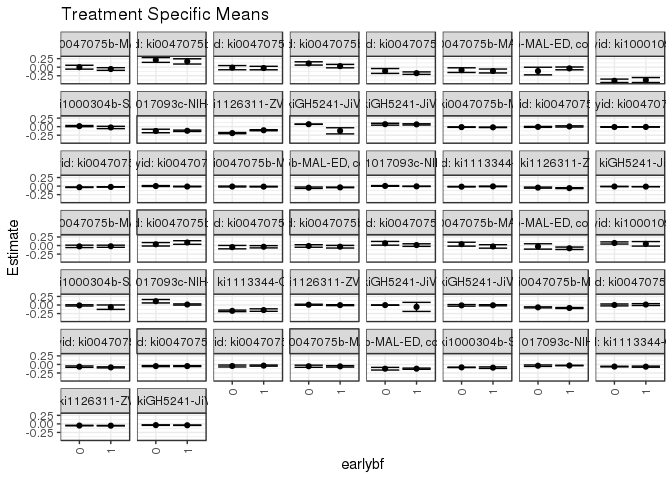

[figure not shown]

## Results Table

### Parameter: TSM

| agecat | studyid | country | intervention_level | baseline_level | estimate | ci_lower | ci_upper |
| --- | --- | --- | --- | --- | --- | --- | --- |
| 0-3 months | ki0047075b-MAL-ED | BANGLADESH | 0 | NA | -0.0004876 | -0.0570413 | 0.0560660 |
| 0-3 months | ki0047075b-MAL-ED | BANGLADESH | 1 | NA | -0.0539070 | -0.0922571 | -0.0155569 |
| 0-3 months | ki0047075b-MAL-ED | BRAZIL | 0 | NA | 0.2110830 | 0.1405928 | 0.2815733 |
| 0-3 months | ki0047075b-MAL-ED | BRAZIL | 1 | NA | 0.1690268 | 0.0926793 | 0.2453743 |
| 0-3 months | ki0047075b-MAL-ED | INDIA | 0 | NA | -0.0133780 | -0.0747128 | 0.0479568 |
| 0-3 months | ki0047075b-MAL-ED | INDIA | 1 | NA | -0.0252734 | -0.0762072 | 0.0256604 |
| 0-3 months | ki0047075b-MAL-ED | NEPAL | 0 | NA | 0.1096373 | 0.0621630 | 0.1571115 |
| 0-3 months | ki0047075b-MAL-ED | NEPAL | 1 | NA | 0.0310734 | -0.0193666 | 0.0815134 |
| 0-3 months | ki0047075b-MAL-ED | PERU | 0 | NA | -0.1102339 | -0.1814549 | -0.0390128 |
| 0-3 months | ki0047075b-MAL-ED | PERU | 1 | NA | -0.1741454 | -0.2101465 | -0.1381442 |
| 0-3 months | ki0047075b-MAL-ED | SOUTH AFRICA | 0 | NA | -0.0859016 | -0.1542820 | -0.0175213 |
| 0-3 months | ki0047075b-MAL-ED | SOUTH AFRICA | 1 | NA | -0.1108755 | -0.1679782 | -0.0537729 |
| 0-3 months | ki0047075b-MAL-ED | TANZANIA, UNITED REPUBLIC OF | 0 | NA | -0.1131540 | -0.2244211 | -0.0018868 |
| 0-3 months | ki0047075b-MAL-ED | TANZANIA, UNITED REPUBLIC OF | 1 | NA | -0.0352855 | -0.0761396 | 0.0055686 |
| 0-3 months | ki1000109-EE | PAKISTAN | 0 | NA | -0.3981282 | -0.4476291 | -0.3486274 |
| 0-3 months | ki1000109-EE | PAKISTAN | 1 | NA | -0.3746070 | -0.4472021 | -0.3020119 |
| 0-3 months | ki1000304b-SAS-CompFeed | INDIA | 0 | NA | 0.0152660 | -0.0017643 | 0.0322964 |
| 0-3 months | ki1000304b-SAS-CompFeed | INDIA | 1 | NA | -0.0234810 | -0.0571934 | 0.0102314 |
| 0-3 months | ki1017093c-NIH-Crypto | BANGLADESH | 0 | NA | -0.1271197 | -0.1782303 | -0.0760091 |
| 0-3 months | ki1017093c-NIH-Crypto | BANGLADESH | 1 | NA | -0.1212884 | -0.1407479 | -0.1018289 |
| 0-3 months | ki1126311-ZVITAMBO | ZIMBABWE | 0 | NA | -0.1890362 | -0.2055807 | -0.1724916 |
| 0-3 months | ki1126311-ZVITAMBO | ZIMBABWE | 1 | NA | -0.1050255 | -0.1198629 | -0.0901881 |
| 0-3 months | kiGH5241-JiVitA-3 | BANGLADESH | 0 | NA | 0.0710564 | 0.0660927 | 0.0760200 |
| 0-3 months | kiGH5241-JiVitA-3 | BANGLADESH | 1 | NA | -0.1222122 | -0.2121055 | -0.0323189 |
| 0-3 months | kiGH5241-JiVitA-4 | BANGLADESH | 0 | NA | 0.0711678 | 0.0438349 | 0.0985007 |
| 0-3 months | kiGH5241-JiVitA-4 | BANGLADESH | 1 | NA | 0.0657908 | 0.0477333 | 0.0838484 |
| 3-6 months | ki0047075b-MAL-ED | BANGLADESH | 0 | NA | -0.0241571 | -0.0589121 | 0.0105980 |
| 3-6 months | ki0047075b-MAL-ED | BANGLADESH | 1 | NA | -0.0203749 | -0.0512123 | 0.0104624 |
| 3-6 months | ki0047075b-MAL-ED | BRAZIL | 0 | NA | 0.0369362 | -0.0134442 | 0.0873167 |
| 3-6 months | ki0047075b-MAL-ED | BRAZIL | 1 | NA | 0.0885075 | 0.0361252 | 0.1408898 |

[output cut: 70 more lines]

### Parameter: E(Y)

| agecat | studyid | country | intervention_level | baseline_level | estimate | ci_lower | ci_upper |
| --- | --- | --- | --- | --- | --- | --- | --- |
| 0-3 months | ki0047075b-MAL-ED | BANGLADESH | NA | NA | -0.0336824 | -0.0658849 | -0.0014799 |
| 0-3 months | ki0047075b-MAL-ED | BRAZIL | NA | NA | 0.1928587 | 0.1409027 | 0.2448147 |
| 0-3 months | ki0047075b-MAL-ED | INDIA | NA | NA | -0.0204797 | -0.0596747 | 0.0187152 |
| 0-3 months | ki0047075b-MAL-ED | NEPAL | NA | NA | 0.0746202 | 0.0395269 | 0.1097135 |
| 0-3 months | ki0047075b-MAL-ED | PERU | NA | NA | -0.1581085 | -0.1906285 | -0.1255886 |
| 0-3 months | ki0047075b-MAL-ED | SOUTH AFRICA | NA | NA | -0.1020352 | -0.1461845 | -0.0578859 |
| 0-3 months | ki0047075b-MAL-ED | TANZANIA, UNITED REPUBLIC OF | NA | NA | -0.0461667 | -0.0847570 | -0.0075763 |
| 0-3 months | ki1000109-EE | PAKISTAN | NA | NA | -0.3938516 | -0.4364614 | -0.3512419 |
| 0-3 months | ki1000304b-SAS-CompFeed | INDIA | NA | NA | 0.0123467 | -0.0036133 | 0.0283068 |
| 0-3 months | ki1017093c-NIH-Crypto | BANGLADESH | NA | NA | -0.1220821 | -0.1402761 | -0.1038881 |
| 0-3 months | ki1126311-ZVITAMBO | ZIMBABWE | NA | NA | -0.1442586 | -0.1553584 | -0.1331588 |
| 0-3 months | kiGH5241-JiVitA-3 | BANGLADESH | NA | NA | 0.0705261 | 0.0655716 | 0.0754805 |
| 0-3 months | kiGH5241-JiVitA-4 | BANGLADESH | NA | NA | 0.0673143 | 0.0523756 | 0.0822531 |
| 3-6 months | ki0047075b-MAL-ED | BANGLADESH | NA | NA | -0.0218549 | -0.0450356 | 0.0013258 |
| 3-6 months | ki0047075b-MAL-ED | BRAZIL | NA | NA | 0.0604904 | 0.0239698 | 0.0970111 |
| 3-6 months | ki0047075b-MAL-ED | INDIA | NA | NA | -0.0401251 | -0.0685271 | -0.0117231 |
| 3-6 months | ki0047075b-MAL-ED | NEPAL | NA | NA | -0.0214542 | -0.0480456 | 0.0051373 |
| 3-6 months | ki0047075b-MAL-ED | PERU | NA | NA | 0.0273803 | -0.0036374 | 0.0583980 |
| 3-6 months | ki0047075b-MAL-ED | SOUTH AFRICA | NA | NA | -0.0014629 | -0.0396382 | 0.0367125 |
| 3-6 months | ki0047075b-MAL-ED | TANZANIA, UNITED REPUBLIC OF | NA | NA | -0.0705448 | -0.1027245 | -0.0383652 |
| 3-6 months | ki1000109-EE | PAKISTAN | NA | NA | 0.0701161 | 0.0419135 | 0.0983187 |
| 3-6 months | ki1000304b-SAS-CompFeed | INDIA | NA | NA | -0.0166348 | -0.0360336 | 0.0027639 |
| 3-6 months | ki1017093c-NIH-Crypto | BANGLADESH | NA | NA | 0.0267740 | 0.0099602 | 0.0435879 |
| 3-6 months | ki1113344-GMS-Nepal | NEPAL | NA | NA | -0.1643126 | -0.1830906 | -0.1455346 |
| 3-6 months | ki1126311-ZVITAMBO | ZIMBABWE | NA | NA | 0.0013347 | -0.0085345 | 0.0112039 |
| 3-6 months | kiGH5241-JiVitA-3 | BANGLADESH | NA | NA | -0.0034526 | -0.0083193 | 0.0014141 |
| 3-6 months | kiGH5241-JiVitA-4 | BANGLADESH | NA | NA | -0.0090589 | -0.0227889 | 0.0046710 |
| 6-12 months | ki0047075b-MAL-ED | BANGLADESH | NA | NA | -0.0803907 | -0.0907811 | -0.0700002 |
| 6-12 months | ki0047075b-MAL-ED | BRAZIL | NA | NA | 0.0065644 | -0.0129183 | 0.0260472 |
| 6-12 months | ki0047075b-MAL-ED | INDIA | NA | NA | -0.0776724 | -0.0898619 | -0.0654829 |
| 6-12 months | ki0047075b-MAL-ED | NEPAL | NA | NA | -0.0488126 | -0.0594641 | -0.0381610 |
| 6-12 months | ki0047075b-MAL-ED | PERU | NA | NA | -0.0373127 | -0.0513600 | -0.0232653 |
| 6-12 months | ki0047075b-MAL-ED | SOUTH AFRICA | NA | NA | -0.0546093 | -0.0721102 | -0.0371085 |
| 6-12 months | ki0047075b-MAL-ED | TANZANIA, UNITED REPUBLIC OF | NA | NA | -0.1240143 | -0.1396706 | -0.1083579 |
| 6-12 months | ki1000304b-SAS-CompFeed | INDIA | NA | NA | -0.0862318 | -0.0909003 | -0.0815633 |
| 6-12 months | ki1017093c-NIH-Crypto | BANGLADESH | NA | NA | -0.0315658 | -0.0388594 | -0.0242722 |
| 6-12 months | ki1113344-GMS-Nepal | NEPAL | NA | NA | -0.0629524 | -0.0714846 | -0.0544202 |
| 6-12 months | ki1126311-ZVITAMBO | ZIMBABWE | NA | NA | -0.0501592 | -0.0551386 | -0.0451799 |
| 6-12 months | kiGH5241-JiVitA-4 | BANGLADESH | NA | NA | -0.0383528 | -0.0427166 | -0.0339890 |
| 12-24 months | ki0047075b-MAL-ED | BANGLADESH | NA | NA | -0.0175081 | -0.0228924 | -0.0121238 |
| 12-24 months | ki0047075b-MAL-ED | BRAZIL | NA | NA | -0.0013016 | -0.0119070 | 0.0093038 |
| 12-24 months | ki0047075b-MAL-ED | INDIA | NA | NA | -0.0098833 | -0.0150187 | -0.0047479 |
| 12-24 months | ki0047075b-MAL-ED | NEPAL | NA | NA | -0.0295113 | -0.0345712 | -0.0244514 |
| 12-24 months | ki0047075b-MAL-ED | PERU | NA | NA | -0.0092560 | -0.0162726 | -0.0022393 |
| 12-24 months | ki0047075b-MAL-ED | SOUTH AFRICA | NA | NA | -0.0148687 | -0.0225262 | -0.0072113 |
| 12-24 months | ki0047075b-MAL-ED | TANZANIA, UNITED REPUBLIC OF | NA | NA | -0.0393265 | -0.0471437 | -0.0315094 |
| 12-24 months | ki1017093c-NIH-Crypto | BANGLADESH | NA | NA | -0.0057326 | -0.0097260 | -0.0017391 |
| 12-24 months | ki1113344-GMS-Nepal | NEPAL | NA | NA | -0.0149004 | -0.0201971 | -0.0096037 |
| 12-24 months | ki1126311-ZVITAMBO | ZIMBABWE | NA | NA | -0.0527908 | -0.0626365 | -0.0429450 |
| 12-24 months | kiGH5241-JiVitA-4 | BANGLADESH | NA | NA | -0.0146006 | -0.0164813 | -0.0127200 |

### Parameter: ATE

| agecat | studyid | country | intervention_level | baseline_level | estimate | ci_lower | ci_upper |
| --- | --- | --- | --- | --- | --- | --- | --- |
| 0-3 months | ki0047075b-MAL-ED | BANGLADESH | 0 | 0 | 0.0000000 | 0.0000000 | 0.0000000 |
| 0-3 months | ki0047075b-MAL-ED | BANGLADESH | 1 | 0 | -0.0534193 | -0.1217497 | 0.0149111 |
| 0-3 months | ki0047075b-MAL-ED | BRAZIL | 0 | 0 | 0.0000000 | 0.0000000 | 0.0000000 |
| 0-3 months | ki0047075b-MAL-ED | BRAZIL | 1 | 0 | -0.0420562 | -0.1459688 | 0.0618563 |
| 0-3 months | ki0047075b-MAL-ED | INDIA | 0 | 0 | 0.0000000 | 0.0000000 | 0.0000000 |
| 0-3 months | ki0047075b-MAL-ED | INDIA | 1 | 0 | -0.0118954 | -0.0916212 | 0.0678305 |
| 0-3 months | ki0047075b-MAL-ED | NEPAL | 0 | 0 | 0.0000000 | 0.0000000 | 0.0000000 |
| 0-3 months | ki0047075b-MAL-ED | NEPAL | 1 | 0 | -0.0785639 | -0.1478314 | -0.0092963 |
| 0-3 months | ki0047075b-MAL-ED | PERU | 0 | 0 | 0.0000000 | 0.0000000 | 0.0000000 |
| 0-3 months | ki0047075b-MAL-ED | PERU | 1 | 0 | -0.0639115 | -0.1437145 | 0.0158914 |
| 0-3 months | ki0047075b-MAL-ED | SOUTH AFRICA | 0 | 0 | 0.0000000 | 0.0000000 | 0.0000000 |
| 0-3 months | ki0047075b-MAL-ED | SOUTH AFRICA | 1 | 0 | -0.0249739 | -0.1140614 | 0.0641136 |
| 0-3 months | ki0047075b-MAL-ED | TANZANIA, UNITED REPUBLIC OF | 0 | 0 | 0.0000000 | 0.0000000 | 0.0000000 |
| 0-3 months | ki0047075b-MAL-ED | TANZANIA, UNITED REPUBLIC OF | 1 | 0 | 0.0778685 | -0.0406618 | 0.1963988 |
| 0-3 months | ki1000109-EE | PAKISTAN | 0 | 0 | 0.0000000 | 0.0000000 | 0.0000000 |
| 0-3 months | ki1000109-EE | PAKISTAN | 1 | 0 | 0.0235213 | -0.0643444 | 0.1113870 |
| 0-3 months | ki1000304b-SAS-CompFeed | INDIA | 0 | 0 | 0.0000000 | 0.0000000 | 0.0000000 |
| 0-3 months | ki1000304b-SAS-CompFeed | INDIA | 1 | 0 | -0.0387470 | -0.0730659 | -0.0044282 |
| 0-3 months | ki1017093c-NIH-Crypto | BANGLADESH | 0 | 0 | 0.0000000 | 0.0000000 | 0.0000000 |
| 0-3 months | ki1017093c-NIH-Crypto | BANGLADESH | 1 | 0 | 0.0058313 | -0.0488584 | 0.0605210 |
| 0-3 months | ki1126311-ZVITAMBO | ZIMBABWE | 0 | 0 | 0.0000000 | 0.0000000 | 0.0000000 |
| 0-3 months | ki1126311-ZVITAMBO | ZIMBABWE | 1 | 0 | 0.0840107 | 0.0617875 | 0.1062339 |
| 0-3 months | kiGH5241-JiVitA-3 | BANGLADESH | 0 | 0 | 0.0000000 | 0.0000000 | 0.0000000 |
| 0-3 months | kiGH5241-JiVitA-3 | BANGLADESH | 1 | 0 | -0.1932686 | -0.2835218 | -0.1030153 |
| 0-3 months | kiGH5241-JiVitA-4 | BANGLADESH | 0 | 0 | 0.0000000 | 0.0000000 | 0.0000000 |
| 0-3 months | kiGH5241-JiVitA-4 | BANGLADESH | 1 | 0 | -0.0053770 | -0.0384178 | 0.0276638 |
| 3-6 months | ki0047075b-MAL-ED | BANGLADESH | 0 | 0 | 0.0000000 | 0.0000000 | 0.0000000 |
| 3-6 months | ki0047075b-MAL-ED | BANGLADESH | 1 | 0 | 0.0037821 | -0.0426814 | 0.0502457 |
| 3-6 months | ki0047075b-MAL-ED | BRAZIL | 0 | 0 | 0.0000000 | 0.0000000 | 0.0000000 |
| 3-6 months | ki0047075b-MAL-ED | BRAZIL | 1 | 0 | 0.0515712 | -0.0211068 | 0.1242492 |

[output cut: 70 more lines]